# Natural Language Processing Lab 3

- Show All Code
- Hide All Code

Author

Lonny Chen

Published

September 16, 2026

# 1 Objectives

Welcome to the third Natural Language Processing lab!

Today’s objectives are to:

1. 🔢 Explore different **text representations** as vectors of token weights
2. 📐 Calculate **cosine similarities** between documents.
3. 🔎 Build a **search engine** to compare a user query with corpus documents.

# 2 Notebook Setup

**Import packages**

```python
# Data packages
import pandas as pd
pd.set_option('display.max_colwidth', None) #default: 50 chars
pd.set_option('display.max_columns', None) #default: 20 columns
import numpy as np

# NLP packages
import spacy
from sklearn.preprocessing import OneHotEncoder
from sklearn.feature_extraction.text import CountVectorizer, TfidfVectorizer
from sklearn.metrics.pairwise import cosine_similarity
import pymupdf

# Plotting package
import plotly.express as px

# Utility libraries
from pathlib import Path
from itertools import chain
from collections import Counter
```

## 2.1 Toy Corpus

The demonstration corpus comes from the textbook (Lane & Dyshel, 2024) GitHub’s bias_intro.txt and consists of a subset of text from the Wikipedia [page](https://en.wikipedia.org/wiki/Algorithmic_bias) for “Algorithmic bias”.

```python
docs = ['Algorithmic bias describes systematic and repeatable errors in a computer system that create unfair outcomes, such as privileging one arbitrary group of users over others.',
        'Bias can emerge due to many factors, including but not limited to the design of the algorithm or the unintended or unanticipated use or decisions relating to the way data is coded, collected, selected or used to train the algorithm.',
        'Algorithmic bias is found across platforms, including but not limited to search engine results and social media platforms, and can have impacts ranging from inadvertent privacy violations to reinforcing social biases of race, gender, sexuality, and ethnicity.',
        'The study of algorithmic bias is most concerned with algorithms that reflect "systematic and unfair" discrimination.'
       ]
```

## 2.2 SpaCy Pipeline

We setup the spaCy [pipeline](https://spacy.io/usage/processing-pipelines) similarly to Lab 2 and apply it to the toy corpus.

```python
# English language model
#spacy.cli.download('en_core_web_sm') #Download (once)
nlp = spacy.load('en_core_web_sm')

# Callable function used as the custom tokenizer for scikit-learn's *Vectorizer class
def spacy_tokenizer(text):
    '''Returns list of tokens'''
    doc = nlp(text) # Tokenization pipeline
    # MODIFY BELOW: lower_, is_alpha, lemma_, is_stop (normalization from Lab 2)
    tokens = [token.lower_ for token in doc if token.is_alpha]
    return tokens
```

**Apply spaCy pipeline first for some downstream vectorizations and functions**

```python
docs_as_tokens = [spacy_tokenizer(doc) for doc in docs]
for doc in docs_as_tokens:
    print(doc)
```

```
['algorithmic', 'bias', 'describes', 'systematic', 'and', 'repeatable', 'errors', 'in', 'a', 'computer', 'system', 'that', 'create', 'unfair', 'outcomes', 'such', 'as', 'privileging', 'one', 'arbitrary', 'group', 'of', 'users', 'over', 'others']
['bias', 'can', 'emerge', 'due', 'to', 'many', 'factors', 'including', 'but', 'not', 'limited', 'to', 'the', 'design', 'of', 'the', 'algorithm', 'or', 'the', 'unintended', 'or', 'unanticipated', 'use', 'or', 'decisions', 'relating', 'to', 'the', 'way', 'data', 'is', 'coded', 'collected', 'selected',…
['algorithmic', 'bias', 'is', 'found', 'across', 'platforms', 'including', 'but', 'not', 'limited', 'to', 'search', 'engine', 'results', 'and', 'social', 'media', 'platforms', 'and', 'can', 'have', 'impacts', 'ranging', 'from', 'inadvertent', 'privacy', 'violations', 'to', 'reinforcing', 'social', '…
['the', 'study', 'of', 'algorithmic', 'bias', 'is', 'most', 'concerned', 'with', 'algorithms', 'that', 'reflect', 'systematic', 'and', 'unfair', 'discrimination']
```

## 2.3 Helper Function

**Define function to print sparsity information**

```python
def print_sparsity(X_csr):
    '''Calculates and prints sparsity %'''
    sparsity = 1 - (X_csr.nnz / (X_csr.shape[0] * X_csr.shape[1]))
    print(f'{repr(X_csr)} ... and sparsity {sparsity:.2%}.')
```

# 3 One-Hot Encoding

**One-hot encoding** preserves every token position but requires the most empty space (super sparse!) as EACH document needs a position-term matrix.

Scikit-learn’s [OneHotEncoder](https://scikit-learn.org/stable/modules/generated/sklearn.preprocessing.OneHotEncoder.html) class is not specifically designed for text data so we need to: - Manually create the corpus vocabulary as features for `.fit()` - Reshape the docs as token columns: `[[t] for t in doc_as_tokens]` - Apply the encoding PER-document

**Run steps for using a one-hot encoder to vectorize the toy corpus**

```python
# 1. Configure encoder
onehot_encoder = OneHotEncoder(handle_unknown='ignore')

# 2. Fit to corpus vocabulary
corpus_vocab = sorted(set(t for doc in docs_as_tokens for t in doc)) # all unique tokens
print(f'The vocabulary size is {len(corpus_vocab)} tokens.\n')
onehot_encoder.fit([[t] for t in corpus_vocab])

# 3. Transform (apply encoding) PER-document
def ohe_transform_to_df(encoder, doc_as_tokens):
    '''Transforms OHE matrix and displays as a DataFrame'''
    X_ohe = encoder.transform([[t] for t in doc_as_tokens])
    print_sparsity(X_ohe)
    df_ohe = pd.DataFrame(X_ohe.toarray(), index=doc_as_tokens, columns=encoder.categories_)
    display(df_ohe)
```

```
The vocabulary size is 80 tokens.
```

**MODIFY document index number to view PER-document matrices**

```python
ohe_transform_to_df(onehot_encoder, docs_as_tokens[0])
```

```
<Compressed Sparse Row sparse matrix of dtype 'float64'
    with 25 stored elements and shape (25, 80)> ... and sparsity 98.75%.
```

|  | a | across | algorithm | algorithmic | algorithms | and | arbitrary | as | bias | biases | but | can | coded | collected | computer | concerned | create | data | decisions | describes | design | discrimination | due | emerge | engine | errors | ethnicity | factors | found | … |
| --- | --- | --- | --- | --- | --- | --- | --- | --- | --- | --- | --- | --- | --- | --- | --- | --- | --- | --- | --- | --- | --- | --- | --- | --- | --- | --- | --- | --- | --- | --- |
| algorithmic | 0.0 | 0.0 | 0.0 | 1.0 | 0.0 | 0.0 | 0.0 | 0.0 | 0.0 | 0.0 | 0.0 | 0.0 | 0.0 | 0.0 | 0.0 | 0.0 | 0.0 | 0.0 | 0.0 | 0.0 | 0.0 | 0.0 | 0.0 | 0.0 | 0.0 | 0.0 | 0.0 | 0.0 | 0.0 | … |
| bias | 0.0 | 0.0 | 0.0 | 0.0 | 0.0 | 0.0 | 0.0 | 0.0 | 1.0 | 0.0 | 0.0 | 0.0 | 0.0 | 0.0 | 0.0 | 0.0 | 0.0 | 0.0 | 0.0 | 0.0 | 0.0 | 0.0 | 0.0 | 0.0 | 0.0 | 0.0 | 0.0 | 0.0 | 0.0 | … |
| describes | 0.0 | 0.0 | 0.0 | 0.0 | 0.0 | 0.0 | 0.0 | 0.0 | 0.0 | 0.0 | 0.0 | 0.0 | 0.0 | 0.0 | 0.0 | 0.0 | 0.0 | 0.0 | 0.0 | 1.0 | 0.0 | 0.0 | 0.0 | 0.0 | 0.0 | 0.0 | 0.0 | 0.0 | 0.0 | … |
| systematic | 0.0 | 0.0 | 0.0 | 0.0 | 0.0 | 0.0 | 0.0 | 0.0 | 0.0 | 0.0 | 0.0 | 0.0 | 0.0 | 0.0 | 0.0 | 0.0 | 0.0 | 0.0 | 0.0 | 0.0 | 0.0 | 0.0 | 0.0 | 0.0 | 0.0 | 0.0 | 0.0 | 0.0 | 0.0 | … |
| and | 0.0 | 0.0 | 0.0 | 0.0 | 0.0 | 1.0 | 0.0 | 0.0 | 0.0 | 0.0 | 0.0 | 0.0 | 0.0 | 0.0 | 0.0 | 0.0 | 0.0 | 0.0 | 0.0 | 0.0 | 0.0 | 0.0 | 0.0 | 0.0 | 0.0 | 0.0 | 0.0 | 0.0 | 0.0 | … |
| repeatable | 0.0 | 0.0 | 0.0 | 0.0 | 0.0 | 0.0 | 0.0 | 0.0 | 0.0 | 0.0 | 0.0 | 0.0 | 0.0 | 0.0 | 0.0 | 0.0 | 0.0 | 0.0 | 0.0 | 0.0 | 0.0 | 0.0 | 0.0 | 0.0 | 0.0 | 0.0 | 0.0 | 0.0 | 0.0 | … |
| errors | 0.0 | 0.0 | 0.0 | 0.0 | 0.0 | 0.0 | 0.0 | 0.0 | 0.0 | 0.0 | 0.0 | 0.0 | 0.0 | 0.0 | 0.0 | 0.0 | 0.0 | 0.0 | 0.0 | 0.0 | 0.0 | 0.0 | 0.0 | 0.0 | 0.0 | 1.0 | 0.0 | 0.0 | 0.0 | … |
| in | 0.0 | 0.0 | 0.0 | 0.0 | 0.0 | 0.0 | 0.0 | 0.0 | 0.0 | 0.0 | 0.0 | 0.0 | 0.0 | 0.0 | 0.0 | 0.0 | 0.0 | 0.0 | 0.0 | 0.0 | 0.0 | 0.0 | 0.0 | 0.0 | 0.0 | 0.0 | 0.0 | 0.0 | 0.0 | … |
| a | 1.0 | 0.0 | 0.0 | 0.0 | 0.0 | 0.0 | 0.0 | 0.0 | 0.0 | 0.0 | 0.0 | 0.0 | 0.0 | 0.0 | 0.0 | 0.0 | 0.0 | 0.0 | 0.0 | 0.0 | 0.0 | 0.0 | 0.0 | 0.0 | 0.0 | 0.0 | 0.0 | 0.0 | 0.0 | … |
| computer | 0.0 | 0.0 | 0.0 | 0.0 | 0.0 | 0.0 | 0.0 | 0.0 | 0.0 | 0.0 | 0.0 | 0.0 | 0.0 | 0.0 | 1.0 | 0.0 | 0.0 | 0.0 | 0.0 | 0.0 | 0.0 | 0.0 | 0.0 | 0.0 | 0.0 | 0.0 | 0.0 | 0.0 | 0.0 | … |
| system | 0.0 | 0.0 | 0.0 | 0.0 | 0.0 | 0.0 | 0.0 | 0.0 | 0.0 | 0.0 | 0.0 | 0.0 | 0.0 | 0.0 | 0.0 | 0.0 | 0.0 | 0.0 | 0.0 | 0.0 | 0.0 | 0.0 | 0.0 | 0.0 | 0.0 | 0.0 | 0.0 | 0.0 | 0.0 | … |
| that | 0.0 | 0.0 | 0.0 | 0.0 | 0.0 | 0.0 | 0.0 | 0.0 | 0.0 | 0.0 | 0.0 | 0.0 | 0.0 | 0.0 | 0.0 | 0.0 | 0.0 | 0.0 | 0.0 | 0.0 | 0.0 | 0.0 | 0.0 | 0.0 | 0.0 | 0.0 | 0.0 | 0.0 | 0.0 | … |
| create | 0.0 | 0.0 | 0.0 | 0.0 | 0.0 | 0.0 | 0.0 | 0.0 | 0.0 | 0.0 | 0.0 | 0.0 | 0.0 | 0.0 | 0.0 | 0.0 | 1.0 | 0.0 | 0.0 | 0.0 | 0.0 | 0.0 | 0.0 | 0.0 | 0.0 | 0.0 | 0.0 | 0.0 | 0.0 | … |
| unfair | 0.0 | 0.0 | 0.0 | 0.0 | 0.0 | 0.0 | 0.0 | 0.0 | 0.0 | 0.0 | 0.0 | 0.0 | 0.0 | 0.0 | 0.0 | 0.0 | 0.0 | 0.0 | 0.0 | 0.0 | 0.0 | 0.0 | 0.0 | 0.0 | 0.0 | 0.0 | 0.0 | 0.0 | 0.0 | … |
| outcomes | 0.0 | 0.0 | 0.0 | 0.0 | 0.0 | 0.0 | 0.0 | 0.0 | 0.0 | 0.0 | 0.0 | 0.0 | 0.0 | 0.0 | 0.0 | 0.0 | 0.0 | 0.0 | 0.0 | 0.0 | 0.0 | 0.0 | 0.0 | 0.0 | 0.0 | 0.0 | 0.0 | 0.0 | 0.0 | … |
| such | 0.0 | 0.0 | 0.0 | 0.0 | 0.0 | 0.0 | 0.0 | 0.0 | 0.0 | 0.0 | 0.0 | 0.0 | 0.0 | 0.0 | 0.0 | 0.0 | 0.0 | 0.0 | 0.0 | 0.0 | 0.0 | 0.0 | 0.0 | 0.0 | 0.0 | 0.0 | 0.0 | 0.0 | 0.0 | … |
| as | 0.0 | 0.0 | 0.0 | 0.0 | 0.0 | 0.0 | 0.0 | 1.0 | 0.0 | 0.0 | 0.0 | 0.0 | 0.0 | 0.0 | 0.0 | 0.0 | 0.0 | 0.0 | 0.0 | 0.0 | 0.0 | 0.0 | 0.0 | 0.0 | 0.0 | 0.0 | 0.0 | 0.0 | 0.0 | … |
| privileging | 0.0 | 0.0 | 0.0 | 0.0 | 0.0 | 0.0 | 0.0 | 0.0 | 0.0 | 0.0 | 0.0 | 0.0 | 0.0 | 0.0 | 0.0 | 0.0 | 0.0 | 0.0 | 0.0 | 0.0 | 0.0 | 0.0 | 0.0 | 0.0 | 0.0 | 0.0 | 0.0 | 0.0 | 0.0 | … |
| one | 0.0 | 0.0 | 0.0 | 0.0 | 0.0 | 0.0 | 0.0 | 0.0 | 0.0 | 0.0 | 0.0 | 0.0 | 0.0 | 0.0 | 0.0 | 0.0 | 0.0 | 0.0 | 0.0 | 0.0 | 0.0 | 0.0 | 0.0 | 0.0 | 0.0 | 0.0 | 0.0 | 0.0 | 0.0 | … |
| arbitrary | 0.0 | 0.0 | 0.0 | 0.0 | 0.0 | 0.0 | 1.0 | 0.0 | 0.0 | 0.0 | 0.0 | 0.0 | 0.0 | 0.0 | 0.0 | 0.0 | 0.0 | 0.0 | 0.0 | 0.0 | 0.0 | 0.0 | 0.0 | 0.0 | 0.0 | 0.0 | 0.0 | 0.0 | 0.0 | … |
| group | 0.0 | 0.0 | 0.0 | 0.0 | 0.0 | 0.0 | 0.0 | 0.0 | 0.0 | 0.0 | 0.0 | 0.0 | 0.0 | 0.0 | 0.0 | 0.0 | 0.0 | 0.0 | 0.0 | 0.0 | 0.0 | 0.0 | 0.0 | 0.0 | 0.0 | 0.0 | 0.0 | 0.0 | 0.0 | … |
| of | 0.0 | 0.0 | 0.0 | 0.0 | 0.0 | 0.0 | 0.0 | 0.0 | 0.0 | 0.0 | 0.0 | 0.0 | 0.0 | 0.0 | 0.0 | 0.0 | 0.0 | 0.0 | 0.0 | 0.0 | 0.0 | 0.0 | 0.0 | 0.0 | 0.0 | 0.0 | 0.0 | 0.0 | 0.0 | … |
| users | 0.0 | 0.0 | 0.0 | 0.0 | 0.0 | 0.0 | 0.0 | 0.0 | 0.0 | 0.0 | 0.0 | 0.0 | 0.0 | 0.0 | 0.0 | 0.0 | 0.0 | 0.0 | 0.0 | 0.0 | 0.0 | 0.0 | 0.0 | 0.0 | 0.0 | 0.0 | 0.0 | 0.0 | 0.0 | … |
| over | 0.0 | 0.0 | 0.0 | 0.0 | 0.0 | 0.0 | 0.0 | 0.0 | 0.0 | 0.0 | 0.0 | 0.0 | 0.0 | 0.0 | 0.0 | 0.0 | 0.0 | 0.0 | 0.0 | 0.0 | 0.0 | 0.0 | 0.0 | 0.0 | 0.0 | 0.0 | 0.0 | 0.0 | 0.0 | … |
| others | 0.0 | 0.0 | 0.0 | 0.0 | 0.0 | 0.0 | 0.0 | 0.0 | 0.0 | 0.0 | 0.0 | 0.0 | 0.0 | 0.0 | 0.0 | 0.0 | 0.0 | 0.0 | 0.0 | 0.0 | 0.0 | 0.0 | 0.0 | 0.0 | 0.0 | 0.0 | 0.0 | 0.0 | 0.0 | … |

# 4 Bag of Words Vectorization

## 4.1 CountVectorizer

Scikit-learn’s [CountVectorizer](https://scikit-learn.org/stable/modules/generated/sklearn.feature_extraction.text.CountVectorizer.html) class vectorizes lists of documents (corpus) into a “Bag of Words” **vector for each document** resulting in (one type of) **document-term matrix** to represent the entire corpus. The values are simply the count of word occurrences, without any position information, thus the name of “Bag” 💰 of Words 🔤.

Steps for usage are:

1. Instantiate `CountVectorizer` and configure options
2. `fit` to corpus vocabulary (can be combined with transform)
3. `transform` corpus of documents into a sparse **document-term matrix**

## 4.2 Tokenization and Normalization (vs. spaCy)

CountVectorizer can also wrap SOME tokenization and normalization steps that overlap with **spaCy**:

- Tokenization ⚠️
  - Regex: 2+ character alphanumeric word boundaries (default) (Option A)
  - OR use **spaCy** linguistic tokenizer (Options B/C)
- Case folding ✅
  - `lowercase` (default)
- Lemmatization ❌
  - use **spaCy** `token.lemma_` (Options B/C)
- Stop words ⚠️
  - Optional `stop_words` using provided `'english'` or custom list
  - OR use **spaCy** `token.is_stop` (Options B/C)
  - … but recall [warnings](https://scikit-learn.org/stable/modules/feature_extraction.html#stop-words)

```python
bow_vectorizer_a = CountVectorizer(
    token_pattern = r"(?u)\b\w\w+\b" # default pattern = r"(?u)\b\w\w+\b"
)
bow_vectorizer_a.fit(docs)
print(f'The vocabulary size is {len(bow_vectorizer_a.vocabulary_)} tokens.')
bow_vectorizer_a.get_feature_names_out()
```

```
The vocabulary size is 79 tokens.
```

```
array(['across', 'algorithm', 'algorithmic', 'algorithms', 'and',
       'arbitrary', 'as', 'bias', 'biases', 'but', 'can', 'coded',
       'collected', 'computer', 'concerned', 'create', 'data',
       'decisions', 'describes', 'design', 'discrimination', 'due',
       'emerge', 'engine', 'errors', 'ethnicity', 'factors', 'found',
       'from', 'gender', 'group', 'have', 'impacts', 'in', 'inadvertent',
       'including', 'is', 'limited', 'many', 'media', 'most', 'not', 'of',
       'one', 'or', 'others', 'outcomes', 'over', 'platforms', 'privacy',
       'privileging', 'race', 'ranging', 'reflect', 'reinforcing',
       'relating', 'repeatable', 'results', 'search', 'selected',
       'sexuality', 'social', 'study', 'such', 'system', 'systematic',
       'that', 'the', 'to', 'train', 'unanticipated', 'unfair',
       'unintended', 'use', 'used', 'users', 'violations', 'way', 'with'],
      dtype=object)
```

```python
bow_vectorizer_b = CountVectorizer(
    tokenizer = spacy_tokenizer # function defined above
)
bow_vectorizer_b.fit(docs)
print(f'The vocabulary size is {len(bow_vectorizer_b.vocabulary_)} tokens.')
bow_vectorizer_b.get_feature_names_out()
```

```
The vocabulary size is 80 tokens.
```

```
array(['a', 'across', 'algorithm', 'algorithmic', 'algorithms', 'and',
       'arbitrary', 'as', 'bias', 'biases', 'but', 'can', 'coded',
       'collected', 'computer', 'concerned', 'create', 'data',
       'decisions', 'describes', 'design', 'discrimination', 'due',
       'emerge', 'engine', 'errors', 'ethnicity', 'factors', 'found',
       'from', 'gender', 'group', 'have', 'impacts', 'in', 'inadvertent',
       'including', 'is', 'limited', 'many', 'media', 'most', 'not', 'of',
       'one', 'or', 'others', 'outcomes', 'over', 'platforms', 'privacy',
       'privileging', 'race', 'ranging', 'reflect', 'reinforcing',
       'relating', 'repeatable', 'results', 'search', 'selected',
       'sexuality', 'social', 'study', 'such', 'system', 'systematic',
       'that', 'the', 'to', 'train', 'unanticipated', 'unfair',
       'unintended', 'use', 'used', 'users', 'violations', 'way', 'with'],
      dtype=object)
```

```python
bow_vectorizer_c = CountVectorizer(
    analyzer=lambda tokens: tokens, # disable, only count-vectorize input tokens
)
bow_vectorizer_c.fit(docs_as_tokens) # already as tokens for Option C
print(f'The vocabulary size is {len(bow_vectorizer_c.vocabulary_)} tokens\n')
bow_vectorizer_c.get_feature_names_out()
```

```
The vocabulary size is 80 tokens
```

```
array(['a', 'across', 'algorithm', 'algorithmic', 'algorithms', 'and',
       'arbitrary', 'as', 'bias', 'biases', 'but', 'can', 'coded',
       'collected', 'computer', 'concerned', 'create', 'data',
       'decisions', 'describes', 'design', 'discrimination', 'due',
       'emerge', 'engine', 'errors', 'ethnicity', 'factors', 'found',
       'from', 'gender', 'group', 'have', 'impacts', 'in', 'inadvertent',
       'including', 'is', 'limited', 'many', 'media', 'most', 'not', 'of',
       'one', 'or', 'others', 'outcomes', 'over', 'platforms', 'privacy',
       'privileging', 'race', 'ranging', 'reflect', 'reinforcing',
       'relating', 'repeatable', 'results', 'search', 'selected',
       'sexuality', 'social', 'study', 'such', 'system', 'systematic',
       'that', 'the', 'to', 'train', 'unanticipated', 'unfair',
       'unintended', 'use', 'used', 'users', 'violations', 'way', 'with'],
      dtype=object)
```

## 4.3 Compressed Sparse Row Matrix

The output of `transform` is a space-saving format called Compressed Sparse Row ([CSR](https://docs.scipy.org/doc/scipy/reference/generated/scipy.sparse.csr_matrix.html)) Matrix from SciPy.

```python
X_bow = bow_vectorizer_b.transform(docs)
print(type(X_bow))
print_sparsity(X_bow)
```

```
<class 'scipy.sparse._csr.csr_matrix'>
<Compressed Sparse Row sparse matrix of dtype 'int64'
    with 102 stored elements and shape (4, 80)> ... and sparsity 68.12%.
```

Using its `.toarray()` method, the CSR matrix can be converted to a full NumPy ndarray and then wrapped in a Pandas `DataFrame` with:

- the **documents** in the rows (or index)
- the tokens/**terms**/features in the columns

… hence the term **document-term matrix**. Of course, this becomes very large for larger datasets so keep the data in a CSER matrix in your working NLP pipeline.

```python
print(f'The vocabulary size is {len(bow_vectorizer_b.get_feature_names_out())} tokens\n')
pd.DataFrame(X_bow.toarray(), index=docs, columns=bow_vectorizer_b.get_feature_names_out())
```

```
The vocabulary size is 80 tokens
```

|  | a | across | algorithm | algorithmic | algorithms | and | arbitrary | as | bias | biases | but | can | coded | collected | computer | concerned | create | data | decisions | describes | design | discrimination | due | emerge | engine | errors | ethnicity | factors | found | … |
| --- | --- | --- | --- | --- | --- | --- | --- | --- | --- | --- | --- | --- | --- | --- | --- | --- | --- | --- | --- | --- | --- | --- | --- | --- | --- | --- | --- | --- | --- | --- |
| Algorithmic bias describes systematic and repeatable errors in a computer system that create unfair outcomes, such as privileging one arbitrary group of users over others. | 1 | 0 | 0 | 1 | 0 | 1 | 1 | 1 | 1 | 0 | 0 | 0 | 0 | 0 | 1 | 0 | 1 | 0 | 0 | 1 | 0 | 0 | 0 | 0 | 0 | 1 | 0 | 0 | 0 | … |
| Bias can emerge due to many factors, including but not limited to the design of the algorithm or the unintended or unanticipated use or decisions relating to the way data is coded, collected, selected… | 0 | 0 | 2 | 0 | 0 | 0 | 0 | 0 | 1 | 0 | 1 | 1 | 1 | 1 | 0 | 0 | 0 | 1 | 1 | 0 | 1 | 0 | 1 | 1 | 0 | 0 | 0 | 1 | 0 | … |
| Algorithmic bias is found across platforms, including but not limited to search engine results and social media platforms, and can have impacts ranging from inadvertent privacy violations to reinforci… | 0 | 1 | 0 | 1 | 0 | 3 | 0 | 0 | 1 | 1 | 1 | 1 | 0 | 0 | 0 | 0 | 0 | 0 | 0 | 0 | 0 | 0 | 0 | 0 | 1 | 0 | 1 | 0 | 1 | … |
| The study of algorithmic bias is most concerned with algorithms that reflect "systematic and unfair" discrimination. | 0 | 0 | 0 | 1 | 1 | 1 | 0 | 0 | 1 | 0 | 0 | 0 | 0 | 0 | 0 | 1 | 0 | 0 | 0 | 0 | 0 | 1 | 0 | 0 | 0 | 0 | 0 | 0 | 0 | … |

## 4.4 Binary vs, Counts

The `binary` parameter replaces token counts with a binary `1` (presence) or `0` (absence) in the vector. This is useful if the downstream task relies more on a term appearing at all rather than the number of appearances.

```python
bin_vectorizer = CountVectorizer(
    tokenizer = spacy_tokenizer,
    binary = True
)
X_bin = bin_vectorizer.fit_transform(docs)
print(f'The vocabulary size is {len(bin_vectorizer.vocabulary_)} tokens\n')
print_sparsity(X_bin)
pd.DataFrame(X_bin.toarray(), index=docs, columns=bin_vectorizer.get_feature_names_out())
```

```
The vocabulary size is 80 tokens

<Compressed Sparse Row sparse matrix of dtype 'int64'
    with 102 stored elements and shape (4, 80)> ... and sparsity 68.12%.
```

|  | a | across | algorithm | algorithmic | algorithms | and | arbitrary | as | bias | biases | but | can | coded | collected | computer | concerned | create | data | decisions | describes | design | discrimination | due | emerge | engine | errors | ethnicity | factors | found | … |
| --- | --- | --- | --- | --- | --- | --- | --- | --- | --- | --- | --- | --- | --- | --- | --- | --- | --- | --- | --- | --- | --- | --- | --- | --- | --- | --- | --- | --- | --- | --- |
| Algorithmic bias describes systematic and repeatable errors in a computer system that create unfair outcomes, such as privileging one arbitrary group of users over others. | 1 | 0 | 0 | 1 | 0 | 1 | 1 | 1 | 1 | 0 | 0 | 0 | 0 | 0 | 1 | 0 | 1 | 0 | 0 | 1 | 0 | 0 | 0 | 0 | 0 | 1 | 0 | 0 | 0 | … |
| Bias can emerge due to many factors, including but not limited to the design of the algorithm or the unintended or unanticipated use or decisions relating to the way data is coded, collected, selected… | 0 | 0 | 1 | 0 | 0 | 0 | 0 | 0 | 1 | 0 | 1 | 1 | 1 | 1 | 0 | 0 | 0 | 1 | 1 | 0 | 1 | 0 | 1 | 1 | 0 | 0 | 0 | 1 | 0 | … |
| Algorithmic bias is found across platforms, including but not limited to search engine results and social media platforms, and can have impacts ranging from inadvertent privacy violations to reinforci… | 0 | 1 | 0 | 1 | 0 | 1 | 0 | 0 | 1 | 1 | 1 | 1 | 0 | 0 | 0 | 0 | 0 | 0 | 0 | 0 | 0 | 0 | 0 | 0 | 1 | 0 | 1 | 0 | 1 | … |
| The study of algorithmic bias is most concerned with algorithms that reflect "systematic and unfair" discrimination. | 0 | 0 | 0 | 1 | 1 | 1 | 0 | 0 | 1 | 0 | 0 | 0 | 0 | 0 | 0 | 1 | 0 | 0 | 0 | 0 | 0 | 1 | 0 | 0 | 0 | 0 | 0 | 0 | 0 | … |

## 4.5 Corpus-Specific Normalization

CountVectorizer also provides some **corpus-specific** normalization parameters that can be useful in controlling the number of features in your vector representation which can affect your downstream task. They are:

- `max_df`: remove common terms by maximum document frequency [0.0, 1.0] (or absolute count)
- `min_df`: remove very rare terms by minimum absolute count integer (or document frequency)
- `max_features`: limit vocabulary size, keeping the top terms by corpus frequency

`max_df` can be used for **removing corpus-specific stop words** but this does not guarantee benefit to your downstream task. We should always empirically justify their removal!

```python
bow_vectorizer_norm = CountVectorizer(
    tokenizer = spacy_tokenizer,
    max_df = 1.0, # default 1,0 (100%) #MODIFY
    min_df = 1, # default 1 #MODIFY
    max_features = None #default None #MODIFY
)
X_norm = bow_vectorizer_norm.fit_transform(docs)
print(f'The vocabulary size is {len(bow_vectorizer_norm.get_feature_names_out())} tokens\n')
print_sparsity(X_norm)
pd.DataFrame(X_norm.toarray(), index=docs, columns=bow_vectorizer_norm.get_feature_names_out())
```

```
The vocabulary size is 80 tokens

<Compressed Sparse Row sparse matrix of dtype 'int64'
    with 102 stored elements and shape (4, 80)> ... and sparsity 68.12%.
```

|  | a | across | algorithm | algorithmic | algorithms | and | arbitrary | as | bias | biases | but | can | coded | collected | computer | concerned | create | data | decisions | describes | design | discrimination | due | emerge | engine | errors | ethnicity | factors | found | … |
| --- | --- | --- | --- | --- | --- | --- | --- | --- | --- | --- | --- | --- | --- | --- | --- | --- | --- | --- | --- | --- | --- | --- | --- | --- | --- | --- | --- | --- | --- | --- |
| Algorithmic bias describes systematic and repeatable errors in a computer system that create unfair outcomes, such as privileging one arbitrary group of users over others. | 1 | 0 | 0 | 1 | 0 | 1 | 1 | 1 | 1 | 0 | 0 | 0 | 0 | 0 | 1 | 0 | 1 | 0 | 0 | 1 | 0 | 0 | 0 | 0 | 0 | 1 | 0 | 0 | 0 | … |
| Bias can emerge due to many factors, including but not limited to the design of the algorithm or the unintended or unanticipated use or decisions relating to the way data is coded, collected, selected… | 0 | 0 | 2 | 0 | 0 | 0 | 0 | 0 | 1 | 0 | 1 | 1 | 1 | 1 | 0 | 0 | 0 | 1 | 1 | 0 | 1 | 0 | 1 | 1 | 0 | 0 | 0 | 1 | 0 | … |
| Algorithmic bias is found across platforms, including but not limited to search engine results and social media platforms, and can have impacts ranging from inadvertent privacy violations to reinforci… | 0 | 1 | 0 | 1 | 0 | 3 | 0 | 0 | 1 | 1 | 1 | 1 | 0 | 0 | 0 | 0 | 0 | 0 | 0 | 0 | 0 | 0 | 0 | 0 | 1 | 0 | 1 | 0 | 1 | … |
| The study of algorithmic bias is most concerned with algorithms that reflect "systematic and unfair" discrimination. | 0 | 0 | 0 | 1 | 1 | 1 | 0 | 0 | 1 | 0 | 0 | 0 | 0 | 0 | 0 | 1 | 0 | 0 | 0 | 0 | 0 | 1 | 0 | 0 | 0 | 0 | 0 | 0 | 0 | … |

# 5 Bag of N-Grams Vectorization

The `ngram_range` parameter is used to tokenize by N-grams, i.e., contiguous sequences of N neighbouring tokens. This results in an increasing vocabulary size (and sparsity) as more types of N-grams are added. For example, this could be useful for sentiment analysis to keep negation 2-grams such as “does not” and “not good”.

`max_features` can be used to control the vocabulary size.

```python
ngram_vectorizer = CountVectorizer(
    tokenizer = spacy_tokenizer,
    ngram_range = (1, 2), # default (1, 1), unigrams only # MODIFY
    max_features = None
)
X_ngram = ngram_vectorizer.fit_transform(docs)
print(f'The vocabulary size is {len(ngram_vectorizer.vocabulary_)} tokens\n')
print_sparsity(X_ngram)
pd.DataFrame(X_ngram.toarray(), index=docs, columns=ngram_vectorizer.get_feature_names_out())
```

```
The vocabulary size is 184 tokens

<Compressed Sparse Row sparse matrix of dtype 'int64'
    with 214 stored elements and shape (4, 184)> ... and sparsity 70.92%.
```

|  | a | a computer | across | across platforms | algorithm | algorithm or | algorithmic | algorithmic bias | algorithms | algorithms that | and | and can | and ethnicity | and repeatable | and social | and unfair | arbitrary | arbitrary group | as | as privileging | bias | bias can | bias describes | bias is | biases | biases of | but | but not | can | … |
| --- | --- | --- | --- | --- | --- | --- | --- | --- | --- | --- | --- | --- | --- | --- | --- | --- | --- | --- | --- | --- | --- | --- | --- | --- | --- | --- | --- | --- | --- | --- |
| Algorithmic bias describes systematic and repeatable errors in a computer system that create unfair outcomes, such as privileging one arbitrary group of users over others. | 1 | 1 | 0 | 0 | 0 | 0 | 1 | 1 | 0 | 0 | 1 | 0 | 0 | 1 | 0 | 0 | 1 | 1 | 1 | 1 | 1 | 0 | 1 | 0 | 0 | 0 | 0 | 0 | 0 | … |
| Bias can emerge due to many factors, including but not limited to the design of the algorithm or the unintended or unanticipated use or decisions relating to the way data is coded, collected, selected… | 0 | 0 | 0 | 0 | 2 | 1 | 0 | 0 | 0 | 0 | 0 | 0 | 0 | 0 | 0 | 0 | 0 | 0 | 0 | 0 | 1 | 1 | 0 | 0 | 0 | 0 | 1 | 1 | 1 | … |
| Algorithmic bias is found across platforms, including but not limited to search engine results and social media platforms, and can have impacts ranging from inadvertent privacy violations to reinforci… | 0 | 0 | 1 | 1 | 0 | 0 | 1 | 1 | 0 | 0 | 3 | 1 | 1 | 0 | 1 | 0 | 0 | 0 | 0 | 0 | 1 | 0 | 0 | 1 | 1 | 1 | 1 | 1 | 1 | … |
| The study of algorithmic bias is most concerned with algorithms that reflect "systematic and unfair" discrimination. | 0 | 0 | 0 | 0 | 0 | 0 | 1 | 1 | 1 | 1 | 1 | 0 | 0 | 0 | 0 | 1 | 0 | 0 | 0 | 0 | 1 | 0 | 0 | 1 | 0 | 0 | 0 | 0 | 0 | … |

# 6 TF-IDF Vectorization

Based on the idea that the “rarity” of a word at the corpus level indicates useful information about a word’s presence in a document, we now move to the idea of **Term Frequency - Inverse Document Frequency** as a calculated weight in the **document-term matrix** (yes, same shape as Bag of Words vectors, all else equal).

## 6.1 TF-IDF Math

The general idea is multiplying two values for each token/term:

1. **Term Frequency** $TF(t,d)$: how often does the term appear in THIS document?
2. **Inverse Document Frequency** $IDF$: how rare is the term relative to the entire corpus?
   - $N_d$: total number of documents
   - $DF(t)$: number of documents the term appears in
   - “Inverse” because we use $\frac{N_d}{DF(t)}$ conceptually (but see below)

This results in: - local (document) importance from $TF(t,d)$ - corpus common words weighted DOWN because of high $DF(t)$ - corpus rare words weighted UP because of low $DF(t)$

The DEFAULT implementation in scikit-learn uses **$IDF=\ln\left(\frac{1+N_d}{1+DF(t)}\right)+1$**, and also scales by dividing by the vector L2 norm $\|\mathbf{A}\|_2 = \sqrt{\sum_{i=1}^{n} A_i^2}$ (see below)

- More about [Tf-idf term weighting](https://scikit-learn.org/stable/modules/feature_extraction.html#tfidf)
- Most about the exact formula used by scikit-learn at TfidfTransformer

**Define function for demonstrating TF-IDF calculation**

```python
def print_math_tfidf(doc, corpus, smooth_idf=True):
    '''Demonstrate calculation of scikit-learn's TF-IDF default weight by building DataFrame'''
    # Get df(t) for each token in doc
    terms = sorted(set(doc))
    doc_freq = {
        t: sum(t in doc for doc in corpus)
        for t in terms
    }
    # Calculate each term of scikit-learn TF-IDF (default) formula
    df = pd.DataFrame(index=terms)
    df['TF(t,d)'] = [doc.count(term) for term in df.index]
    df['Nd'] = len(corpus)
    df['DF(t)'] = [doc_freq[term] for term in df.index]
    if smooth_idf:
        df['IDF = ln( (1+Nd) / (1+DF(t)) ) + 1'] = np.log((1+df['Nd'])/(1+df['DF(t)'])) + 1
        df['TF*IDF'] = df['TF(t,d)'] * df['IDF = ln( (1+Nd) / (1+DF(t)) ) + 1']
    else:
        df['IDF = ln( Nd / DF(t) ) + 1'] = np.log(df['Nd']/df['DF(t)']) + 1
        df['TF*IDF'] = df['TF(t,d)'] * df['IDF = ln( Nd / DF(t) ) + 1']
    df['L2 norm'] = np.linalg.norm(df['TF*IDF'])
    df['TF*IDF / L2'] = df['TF*IDF'] / df['L2 norm']
    return df
```

```python
print_math_tfidf(docs_as_tokens[2], docs_as_tokens)
```

|  | TF(t,d) | Nd | DF(t) | IDF = ln( (1+Nd) / (1+DF(t)) ) + 1 | TF*IDF | L2 norm | TF*IDF / L2 |
| --- | --- | --- | --- | --- | --- | --- | --- |
| across | 1 | 4 | 1 | 1.916291 | 1.916291 | 11.753673 | 0.163038 |
| algorithmic | 1 | 4 | 3 | 1.223144 | 1.223144 | 11.753673 | 0.104065 |
| and | 3 | 4 | 3 | 1.223144 | 3.669431 | 11.753673 | 0.312194 |
| bias | 1 | 4 | 4 | 1.000000 | 1.000000 | 11.753673 | 0.085080 |
| biases | 1 | 4 | 1 | 1.916291 | 1.916291 | 11.753673 | 0.163038 |
| but | 1 | 4 | 2 | 1.510826 | 1.510826 | 11.753673 | 0.128541 |
| can | 1 | 4 | 2 | 1.510826 | 1.510826 | 11.753673 | 0.128541 |
| engine | 1 | 4 | 1 | 1.916291 | 1.916291 | 11.753673 | 0.163038 |
| ethnicity | 1 | 4 | 1 | 1.916291 | 1.916291 | 11.753673 | 0.163038 |
| found | 1 | 4 | 1 | 1.916291 | 1.916291 | 11.753673 | 0.163038 |
| from | 1 | 4 | 1 | 1.916291 | 1.916291 | 11.753673 | 0.163038 |
| gender | 1 | 4 | 1 | 1.916291 | 1.916291 | 11.753673 | 0.163038 |
| have | 1 | 4 | 1 | 1.916291 | 1.916291 | 11.753673 | 0.163038 |
| impacts | 1 | 4 | 1 | 1.916291 | 1.916291 | 11.753673 | 0.163038 |
| inadvertent | 1 | 4 | 1 | 1.916291 | 1.916291 | 11.753673 | 0.163038 |
| including | 1 | 4 | 2 | 1.510826 | 1.510826 | 11.753673 | 0.128541 |
| is | 1 | 4 | 3 | 1.223144 | 1.223144 | 11.753673 | 0.104065 |
| limited | 1 | 4 | 2 | 1.510826 | 1.510826 | 11.753673 | 0.128541 |
| media | 1 | 4 | 1 | 1.916291 | 1.916291 | 11.753673 | 0.163038 |
| not | 1 | 4 | 2 | 1.510826 | 1.510826 | 11.753673 | 0.128541 |
| of | 1 | 4 | 4 | 1.000000 | 1.000000 | 11.753673 | 0.085080 |
| platforms | 2 | 4 | 1 | 1.916291 | 3.832581 | 11.753673 | 0.326075 |
| privacy | 1 | 4 | 1 | 1.916291 | 1.916291 | 11.753673 | 0.163038 |
| race | 1 | 4 | 1 | 1.916291 | 1.916291 | 11.753673 | 0.163038 |
| ranging | 1 | 4 | 1 | 1.916291 | 1.916291 | 11.753673 | 0.163038 |
| reinforcing | 1 | 4 | 1 | 1.916291 | 1.916291 | 11.753673 | 0.163038 |
| results | 1 | 4 | 1 | 1.916291 | 1.916291 | 11.753673 | 0.163038 |
| search | 1 | 4 | 1 | 1.916291 | 1.916291 | 11.753673 | 0.163038 |
| sexuality | 1 | 4 | 1 | 1.916291 | 1.916291 | 11.753673 | 0.163038 |
| social | 2 | 4 | 1 | 1.916291 | 3.832581 | 11.753673 | 0.326075 |
| to | 2 | 4 | 2 | 1.510826 | 3.021651 | 11.753673 | 0.257081 |
| violations | 1 | 4 | 1 | 1.916291 | 1.916291 | 11.753673 | 0.163038 |

## 6.2 TfidfVectorizer

TF-IDF is implemented in scikit-learn with the [TfidfVectorizer](https://scikit-learn.org/stable/modules/generated/sklearn.feature_extraction.text.TfidfVectorizer.html) class, which:

- Includes the SAME tokenization/normalization options as CountVectorizer
- Uses the SAME steps as CountVectorizer
- ⚠️ The default calculation is slightly different than the textbook (and session slides) versions as discussed above.

```python
tfidf_vectorizer = TfidfVectorizer(
    tokenizer = spacy_tokenizer,
    use_idf = True, # default True / False enables TF only (IDF=1)
    smooth_idf = True, # default True (include ones in IDF log numerator and denominator)
    norm = 'l2' # default 'l2' normalization: divide by "Euclidean" length, saves one step in cosine_similarity (2nd power)
)
X_tfidf = tfidf_vectorizer.fit_transform(docs)
print(f'The vocabulary size is {len(tfidf_vectorizer.vocabulary_)} tokens\n')
print_sparsity(X_tfidf)
df_tfidf = pd.DataFrame(X_tfidf.toarray(), index=docs, columns=tfidf_vectorizer.get_feature_names_out())
df_tfidf
```

```
The vocabulary size is 80 tokens

<Compressed Sparse Row sparse matrix of dtype 'float64'
    with 102 stored elements and shape (4, 80)> ... and sparsity 68.12%.
```

|  | a | across | algorithm | algorithmic | algorithms | and | arbitrary | as | bias | biases | but | can | coded | collected | computer | concerned | create | data | decisions | describes | design | discrimination | due | emerge | engine | errors | ethnicity | factors | found | … |
| --- | --- | --- | --- | --- | --- | --- | --- | --- | --- | --- | --- | --- | --- | --- | --- | --- | --- | --- | --- | --- | --- | --- | --- | --- | --- | --- | --- | --- | --- | --- |
| Algorithmic bias describes systematic and repeatable errors in a computer system that create unfair outcomes, such as privileging one arbitrary group of users over others. | 0.217062 | 0.000000 | 0.000000 | 0.138548 | 0.000000 | 0.138548 | 0.217062 | 0.217062 | 0.113272 | 0.000000 | 0.000000 | 0.000000 | 0.000000 | 0.000000 | 0.217062 | 0.000000 | 0.217062 | 0.000000 | 0.000000 | 0.217062 | 0.000000 | 0.000000 | 0.000000 | 0.000000 | 0.000000 | 0.217062 | 0.000000 | 0.000000 | 0.000000 | … |
| Bias can emerge due to many factors, including but not limited to the design of the algorithm or the unintended or unanticipated use or decisions relating to the way data is coded, collected, selected… | 0.000000 | 0.000000 | 0.245172 | 0.000000 | 0.000000 | 0.000000 | 0.000000 | 0.000000 | 0.063971 | 0.000000 | 0.096648 | 0.096648 | 0.122586 | 0.122586 | 0.000000 | 0.000000 | 0.000000 | 0.122586 | 0.122586 | 0.000000 | 0.122586 | 0.000000 | 0.122586 | 0.122586 | 0.000000 | 0.000000 | 0.000000 | 0.122586 | 0.000000 | … |
| Algorithmic bias is found across platforms, including but not limited to search engine results and social media platforms, and can have impacts ranging from inadvertent privacy violations to reinforci… | 0.000000 | 0.163038 | 0.000000 | 0.104065 | 0.000000 | 0.312194 | 0.000000 | 0.000000 | 0.085080 | 0.163038 | 0.128541 | 0.128541 | 0.000000 | 0.000000 | 0.000000 | 0.000000 | 0.000000 | 0.000000 | 0.000000 | 0.000000 | 0.000000 | 0.000000 | 0.000000 | 0.000000 | 0.163038 | 0.000000 | 0.163038 | 0.000000 | 0.163038 | … |
| The study of algorithmic bias is most concerned with algorithms that reflect "systematic and unfair" discrimination. | 0.000000 | 0.000000 | 0.000000 | 0.190273 | 0.298099 | 0.190273 | 0.000000 | 0.000000 | 0.155561 | 0.000000 | 0.000000 | 0.000000 | 0.000000 | 0.000000 | 0.000000 | 0.298099 | 0.000000 | 0.000000 | 0.000000 | 0.000000 | 0.000000 | 0.298099 | 0.000000 | 0.000000 | 0.000000 | 0.000000 | 0.000000 | 0.000000 | 0.000000 | … |

# 7 Tiny Search Engine

Probably the most prominent historical uses of TF-IDF is for **document search engines**. These are based on the cosine similarity between two vectors. We can use scikit-learn’s [cosine_similarity](https://scikit-learn.org/stable/modules/generated/sklearn.metrics.pairwise.cosine_similarity.html) method to calculate document-pair similarities quickly.

**Display document-to-document cosine similarities**

```python
pd.DataFrame(
    cosine_similarity(df_tfidf),
    index=docs,
    columns=docs
)
```

|  | Algorithmic bias describes systematic and repeatable errors in a computer system that create unfair outcomes, such as privileging one arbitrary group of users over others. | Bias can emerge due to many factors, including but not limited to the design of the algorithm or the unintended or unanticipated use or decisions relating to the way data is coded, collected, selected… | Algorithmic bias is found across platforms, including but not limited to search engine results and social media platforms, and can have impacts ranging from inadvertent privacy violations to reinforci… | The study of algorithmic bias is most concerned with algorithms that reflect "systematic and unfair" discrimination. |
| --- | --- | --- | --- | --- |
| Algorithmic bias describes systematic and repeatable errors in a computer system that create unfair outcomes, such as privileging one arbitrary group of users over others. | 1.000000 | 0.014492 | 0.076946 | 0.208628 |
| Bias can emerge due to many factors, including but not limited to the design of the algorithm or the unintended or unanticipated use or decisions relating to the way data is coded, collected, selected… | 0.014492 | 1.000000 | 0.180530 | 0.148364 |
| Algorithmic bias is found across platforms, including but not limited to search engine results and social media platforms, and can have impacts ranging from inadvertent privacy violations to reinforci… | 0.076946 | 0.180530 | 1.000000 | 0.125474 |
| The study of algorithmic bias is most concerned with algorithms that reflect "systematic and unfair" discrimination. | 0.208628 | 0.148364 | 0.125474 | 1.000000 |

## 7.1 Cosine Similarity Math

The **cosine similarity** is one of the primary measures of the directional similarity of any two vectors in N-dimensional space which will be needed to enable our search engine. For any two vectors $A$ and $B$, the calculation consists of:

1. **Dot Product of Pairwise Vector Positions** in the numerator: $\mathbf{A} \cdot \mathbf{B} = \sum_{i=1}^{n} A_i B_i$
2. **Euclidean (L2) norm lengths** in the denominator for scaling: $\|\mathbf{A}\|_2 \|\mathbf{B}\|_2 = \sqrt{\sum_{i=1}^{n} A_i^2}\sqrt{\sum_{i=1}^{n} B_i^2}$

This results in two text documents that:

- share many terms having a cosine similarity closer to 1
- share no or few terms having a cosine similarity closer to 0

**Define function for demonstrating cosine similarity calculation**

```python
def print_math_cosine_similarity(doca, docb, order=False, top_k=10):
    '''docstring'''
    df = pd.DataFrame(index=doca.index)
    df['Ai'] = doca[df.index]
    df['Bi'] = docb[df.index]
    df['Ai * Bi'] = df['Ai'] * df['Bi']
    a_dot_b = df['Ai * Bi'].sum()
    l2_a = np.linalg.norm(df['Ai'])
    l2_b = np.linalg.norm(df['Bi'])
    print(f'SUM(Ai*Bi) = {a_dot_b:.5f}')
    print(f'The L2 norm length of A is ||A|| = {l2_a:.5f}')
    print(f'The L2 norm length of B is ||B|| = {l2_b:.5f}')
    print(f'Cosine similiarity is SUM(Ai*Bi) / (||A||*||B||) : {a_dot_b/(l2_a*l2_b):.5f}')
    if order:
        display(df.sort_values('Ai * Bi', ascending=False).head(top_k))
    else:
        display(df)
```

```python
print_math_cosine_similarity(df_tfidf.iloc[0], df_tfidf.iloc[3], order=True, top_k=10)
```

```
SUM(Ai*Bi) = 0.20863
The L2 norm length of A is ||A|| = 1.00000
The L2 norm length of B is ||B|| = 1.00000
Cosine similiarity is SUM(Ai*Bi) / (||A||*||B||) : 0.20863
```

|  | Ai | Bi | Ai * Bi |
| --- | --- | --- | --- |
| unfair | 0.171134 | 0.235025 | 0.040221 |
| systematic | 0.171134 | 0.235025 | 0.040221 |
| that | 0.171134 | 0.235025 | 0.040221 |
| algorithmic | 0.138548 | 0.190273 | 0.026362 |
| and | 0.138548 | 0.190273 | 0.026362 |
| bias | 0.113272 | 0.155561 | 0.017621 |
| of | 0.113272 | 0.155561 | 0.017621 |
| outcomes | 0.217062 | 0.000000 | 0.000000 |
| others | 0.217062 | 0.000000 | 0.000000 |
| over | 0.217062 | 0.000000 | 0.000000 |

## 7.2 Query Relevance Search

Since any two documents in the corpus can have their similarities calculated, it follows that a **query document**, i.e., the search engine search string, works by having its **cosine similiarity** with all other documents in the corpus calculated and then ranked for relevance.

STEPS:

1. Test out different query strings and see how the toy corpus documents **rank in relevance**.
2. Check for per-term dot products to see which shared **terms contribute most** to the combined cosine similarity.

Code reference: [NLP Demystified](https://colab.research.google.com/github/futuremojo/nlp-demystified/blob/main/notebooks/nlpdemystified_vectorization.ipynb#scrollTo=jEfdfkmpP8Tv)

```python
query_doc = ['What is algorithmic bias?'] # MODIFY HERE

# Vectorize query
query_tfidf = tfidf_vectorizer.transform(query_doc)
df_query = pd.DataFrame(query_tfidf.toarray(), index=query_doc, columns=tfidf_vectorizer.get_feature_names_out())

# Calculate and order document relevance to query
query_similarities = pd.DataFrame(cosine_similarity(X_tfidf, query_tfidf).flatten(), index=docs, columns=query_doc)
query_similarities.sort_values(query_doc, ascending=False)
```

|  | What is algorithmic bias? |
| --- | --- |
| The study of algorithmic bias is most concerned with algorithms that reflect "systematic and unfair" discrimination. | 0.310816 |
| Algorithmic bias is found across platforms, including but not limited to search engine results and social media platforms, and can have impacts ranging from inadvertent privacy violations to reinforci… | 0.169993 |
| Algorithmic bias describes systematic and repeatable errors in a computer system that create unfair outcomes, such as privileging one arbitrary group of users over others. | 0.141507 |
| Bias can emerge due to many factors, including but not limited to the design of the algorithm or the unintended or unanticipated use or decisions relating to the way data is coded, collected, selected… | 0.079916 |

```python
# MODIFY the document index numbers, also `top_k`
print_math_cosine_similarity(df_query.iloc[0], df_tfidf.loc[docs[3]], order=True, top_k=10)
```

```
SUM(Ai*Bi) = 0.31082
The L2 norm length of A is ||A|| = 1.00000
The L2 norm length of B is ||B|| = 1.00000
Cosine similiarity is SUM(Ai*Bi) / (||A||*||B||) : 0.31082
```

|  | Ai | Bi | Ai * Bi |
| --- | --- | --- | --- |
| algorithmic | 0.612172 | 0.190273 | 0.116480 |
| is | 0.612172 | 0.190273 | 0.116480 |
| bias | 0.500491 | 0.155561 | 0.077857 |
| a | 0.000000 | 0.000000 | 0.000000 |
| privileging | 0.000000 | 0.000000 | 0.000000 |
| results | 0.000000 | 0.000000 | 0.000000 |
| repeatable | 0.000000 | 0.000000 | 0.000000 |
| relating | 0.000000 | 0.000000 | 0.000000 |
| reinforcing | 0.000000 | 0.000000 | 0.000000 |
| reflect | 0.000000 | 0.298099 | 0.000000 |

# 8 PDF Search Engine

Let’s scale up our TF-IDF-based search engine for real-life documents, specifically ten Hertie School course syllabi downloaded from the Hertie MyStudies [Course Directory](https://mystudies.hertie-school.org/course-directory.php) filtered for “Fall 2026” (requires login).

You may try searching in any other collection of PDFs by simply pointing to another accessible folder of PDF files or copying them to the current expected folder name and location.

**Defne function for extracting text from a folder of PDF files**

```python
def extract_pdf_text(folder_path):
    '''docstring'''
    folder = Path(folder_path)
    docs = []
    pdf_files = []
    for pdf_file in folder.glob('*.pdf'):
        pdf_files.append(pdf_file.name.removesuffix('.pdf'))
        doc = pymupdf.open(pdf_file)
        text = '\n'.join(page.get_text() for page in doc)
        docs.append(text)
        doc.close()
    return pd.DataFrame({'filename': pdf_files, 'text': docs})
```

```python
df_pdf_text = extract_pdf_text('pdf_corpus') # MODIFY folder location if needed
df_pdf_text.shape
```

```
(10, 2)
```

## 8.1 Configuration Options

You can try a few options found in this lab to improve your search engine’s (subjective of course) performance:

- Use different types of document-term matrix representations: **Bag-of-Words, N-grams, TF-IDF.**
- Apply different tokenization and **normalization** using spaCy and/or scikit-learn `*Vectorizer`.
- Apply **corpus-specific** normaiization using scikit-learn `*Vectorizer`.
- Add **specific stop words** using scikit-learn `*Vectorizer`

```python
def spacy_tokenizer(text):
    doc = nlp(text)
    # MODIFY BELOW: lower_, is_alpha, lemma_, is_stop (normalization from Lab 2)
    tokens = [token.lower_ for token in doc if token.is_alpha]
    return tokens

# MODIFY: type of vectorizer, binary, N-gram, stop words
pdf_vectorizer = TfidfVectorizer( # OR CountVectorizer
    tokenizer = spacy_tokenizer,
    binary = False,
    ngram_range = (1, 1),
    max_df = 1.0,
    min_df = 1,
    max_features = None,
    stop_words = [] # Can input a custom list or 'english'
)

X_pdf = pdf_vectorizer.fit_transform(df_pdf_text['text'])
print(f'The vocabulary size is {len(pdf_vectorizer.vocabulary_)} tokens\n')
print_sparsity(X_pdf)
df_pdf_vec = pd.DataFrame(X_pdf.toarray(), index=df_pdf_text['filename'], columns=pdf_vectorizer.get_feature_names_out())
df_pdf_vec
```

```
The vocabulary size is 5731 tokens

<Compressed Sparse Row sparse matrix of dtype 'float64'
    with 12159 stored elements and shape (10, 5731)> ... and sparsity 78.78%.
```

| filename | a | aaai | aalberg | aaron | abacus | abadie | abaigar | abaraca | abatements | abilities | ability | able | abm | abolitionist | about | above | abraham | abrupt | absolute | abstract | abstraction | abundance | abuse | abzhanov | acad | academia | academic | academy | accept | … |
| --- | --- | --- | --- | --- | --- | --- | --- | --- | --- | --- | --- | --- | --- | --- | --- | --- | --- | --- | --- | --- | --- | --- | --- | --- | --- | --- | --- | --- | --- | --- |
| E1487_CausalMachineLearning_Dimmery | 0.178356 | 0.000000 | 0.000000 | 0.000000 | 0.00000 | 0.007781 | 0.007781 | 0.00000 | 0.000000 | 0.000000 | 0.005787 | 0.008630 | 0.000000 | 0.000000 | 0.010362 | 0.000000 | 0.006614 | 0.000000 | 0.000000 | 0.000000 | 0.000000 | 0.00000 | 0.000000 | 0.000000 | 0.000000 | 0.006614 | 0.005753 | 0.027722 | 0.000000 | … |
| E1282_NaturalLangProcess_RamirezRuiz | 0.123575 | 0.000000 | 0.000000 | 0.000000 | 0.00000 | 0.000000 | 0.000000 | 0.00000 | 0.000000 | 0.000000 | 0.000000 | 0.012784 | 0.000000 | 0.000000 | 0.000000 | 0.000000 | 0.000000 | 0.000000 | 0.000000 | 0.000000 | 0.000000 | 0.00000 | 0.000000 | 0.000000 | 0.000000 | 0.000000 | 0.012784 | 0.000000 | 0.000000 | … |
| E1354_DataScienceDecisionMaking_Lowe | 0.147991 | 0.000000 | 0.000000 | 0.012912 | 0.00000 | 0.000000 | 0.000000 | 0.00000 | 0.000000 | 0.010977 | 0.009603 | 0.004774 | 0.000000 | 0.000000 | 0.017196 | 0.017076 | 0.000000 | 0.000000 | 0.000000 | 0.009603 | 0.000000 | 0.00000 | 0.000000 | 0.000000 | 0.000000 | 0.000000 | 0.023870 | 0.000000 | 0.000000 | … |
| E1368_PoliticsofFood_Bauer | 0.086911 | 0.000000 | 0.000000 | 0.000000 | 0.00511 | 0.000000 | 0.000000 | 0.00511 | 0.000000 | 0.000000 | 0.000000 | 0.001889 | 0.000000 | 0.000000 | 0.018148 | 0.000000 | 0.000000 | 0.000000 | 0.000000 | 0.000000 | 0.000000 | 0.00511 | 0.000000 | 0.000000 | 0.000000 | 0.000000 | 0.013226 | 0.000000 | 0.000000 | … |
| E1319_GPAI_Bryson | 0.139640 | 0.007708 | 0.003854 | 0.000000 | 0.00000 | 0.000000 | 0.000000 | 0.00000 | 0.000000 | 0.000000 | 0.000000 | 0.001425 | 0.000000 | 0.003854 | 0.015398 | 0.005097 | 0.003276 | 0.000000 | 0.000000 | 0.000000 | 0.000000 | 0.00000 | 0.003854 | 0.000000 | 0.000000 | 0.000000 | 0.015674 | 0.000000 | 0.000000 | … |
| E1359_IntergroupRelations_Ditlmann | 0.158381 | 0.000000 | 0.000000 | 0.000000 | 0.00000 | 0.000000 | 0.000000 | 0.00000 | 0.000000 | 0.000000 | 0.000000 | 0.002779 | 0.000000 | 0.000000 | 0.046707 | 0.000000 | 0.000000 | 0.000000 | 0.000000 | 0.000000 | 0.000000 | 0.00000 | 0.000000 | 0.000000 | 0.000000 | 0.000000 | 0.013893 | 0.004463 | 0.000000 | … |
| E1393_DvlpEconomics_Ornaghi | 0.142815 | 0.000000 | 0.000000 | 0.000000 | 0.00000 | 0.000000 | 0.000000 | 0.00000 | 0.011037 | 0.000000 | 0.000000 | 0.016322 | 0.000000 | 0.000000 | 0.019597 | 0.000000 | 0.000000 | 0.000000 | 0.000000 | 0.000000 | 0.000000 | 0.00000 | 0.000000 | 0.000000 | 0.000000 | 0.000000 | 0.016322 | 0.006554 | 0.000000 | … |
| E1461_AgencyFoundationsTechEthics_Bryson | 0.154365 | 0.000000 | 0.000000 | 0.000000 | 0.00000 | 0.000000 | 0.000000 | 0.00000 | 0.000000 | 0.004930 | 0.012938 | 0.015008 | 0.075385 | 0.000000 | 0.018019 | 0.003834 | 0.000000 | 0.005799 | 0.005799 | 0.004313 | 0.005799 | 0.00000 | 0.000000 | 0.005799 | 0.005799 | 0.000000 | 0.015008 | 0.006887 | 0.005799 | … |
| E1287_EmissionsPricing_Hirth&Flachsland | 0.116760 | 0.000000 | 0.000000 | 0.000000 | 0.00000 | 0.000000 | 0.000000 | 0.00000 | 0.000000 | 0.000000 | 0.000000 | 0.004670 | 0.000000 | 0.000000 | 0.000000 | 0.000000 | 0.000000 | 0.000000 | 0.000000 | 0.000000 | 0.000000 | 0.00000 | 0.000000 | 0.000000 | 0.000000 | 0.000000 | 0.023352 | 0.000000 | 0.000000 | … |
| E1508_Evaluating-AI-Systems_Dimmery | 0.211200 | 0.000000 | 0.000000 | 0.000000 | 0.00000 | 0.000000 | 0.000000 | 0.00000 | 0.000000 | 0.000000 | 0.000000 | 0.007040 | 0.000000 | 0.000000 | 0.020287 | 0.002518 | 0.000000 | 0.000000 | 0.000000 | 0.002832 | 0.000000 | 0.00000 | 0.000000 | 0.000000 | 0.000000 | 0.003237 | 0.007040 | 0.002261 | 0.000000 | … |

## 8.2 Query Relevance Search

```python
query_doc = ['natural language processing'] # MODIFY and check scores

# Vectorize query
query_vec = pdf_vectorizer.transform(query_doc)
df_query = pd.DataFrame(query_vec.toarray(), index=query_doc, columns=pdf_vectorizer.get_feature_names_out())

# Calculate and order document relevance to query
query_similarities = pd.DataFrame(cosine_similarity(X_pdf, query_vec).flatten(), index=df_pdf_text['filename'], columns=query_doc)
query_similarities.sort_values(query_doc, ascending=False)
```

| filename | natural language processing |
| --- | --- |
| E1282_NaturalLangProcess_RamirezRuiz | 0.133732 |
| E1508_Evaluating-AI-Systems_Dimmery | 0.018865 |
| E1487_CausalMachineLearning_Dimmery | 0.017026 |
| E1461_AgencyFoundationsTechEthics_Bryson | 0.012588 |
| E1319_GPAI_Bryson | 0.007858 |
| E1354_DataScienceDecisionMaking_Lowe | 0.003291 |
| E1368_PoliticsofFood_Bauer | 0.002500 |
| E1359_IntergroupRelations_Ditlmann | 0.000000 |
| E1393_DvlpEconomics_Ornaghi | 0.000000 |
| E1287_EmissionsPricing_Hirth&Flachsland | 0.000000 |

```python
# MODIFY the file name as index into the vectorized DataFrame, also `top_k`
print_math_cosine_similarity(df_query.iloc[0], df_pdf_vec.loc['E1282_NaturalLangProcess_RamirezRuiz'], order=True, top_k=10)
```

```
SUM(Ai*Bi) = 0.13373
The L2 norm length of A is ||A|| = 1.00000
The L2 norm length of B is ||B|| = 1.00000
Cosine similiarity is SUM(Ai*Bi) / (||A||*||B||) : 0.13373
```

|  | Ai | Bi | Ai * Bi |
| --- | --- | --- | --- |
| natural | 0.657745 | 0.068575 | 0.045105 |
| processing | 0.584782 | 0.076210 | 0.044566 |
| language | 0.474764 | 0.092808 | 0.044062 |
| a | 0.000000 | 0.123575 | 0.000000 |
| persuasive | 0.000000 | 0.000000 | 0.000000 |
| pevec | 0.000000 | 0.000000 | 0.000000 |
| petrikova | 0.000000 | 0.000000 | 0.000000 |
| peters | 0.000000 | 0.000000 | 0.000000 |
| peter | 0.000000 | 0.000000 | 0.000000 |
| pete | 0.000000 | 0.000000 | 0.000000 |

# 9 Bonus!: Zipf’s Law (and why we log the IDF)

How do word frequencies distribute by word ranking? Do you think that the few very common words are much more common than the many many rare words? As it turns out, there is an very interesting law for this called **Zipf’s Law**:

$$f(r) \propto \frac{1}{r^s}$$

… where $r$ is word frequency rank and $s$ is close to 1. In other words, the second most frequent word occurs ~1/2 as often the third ~1/3, and so on. This results in a roughly straight line log-log plot of rank vs. frequency.

**Define function to plot rank vs. frequency (Zipf’s Law)**

```python
def plot_zipf(docs, tokenizer, log_plot=True):
    '''Plot Zipf's Law'''

    # Tokenize/normalize, combine all tokens
    docs_as_tokens = [spacy_tokenizer(doc) for doc in df_pdf_text['text']]
    all_tokens = list(chain.from_iterable(docs_as_tokens))
    len(all_tokens)

    # Count and rank
    freq = Counter(all_tokens)
    dfz = (
        pd.DataFrame(freq.items(), columns=['term', 'frequency'])
          .sort_values('frequency', ascending=False)
          .reset_index(drop=True)
    )
    dfz['rank'] = dfz.index + 1 #sorted

    # Plot
    fig = px.scatter(
        dfz,
        x='rank', y='frequency',
        text='term', # annotate terms
        hover_name='term',
        log_x=log_plot, log_y=log_plot,
        labels={'rank': 'Rank',
                'frequency': 'Frequency'
               },
        title="Zipf's Law for PDF corpus",
        width=800,
        height=800
    )
    fig.update_traces(textposition="middle right")
    fig.show()
```

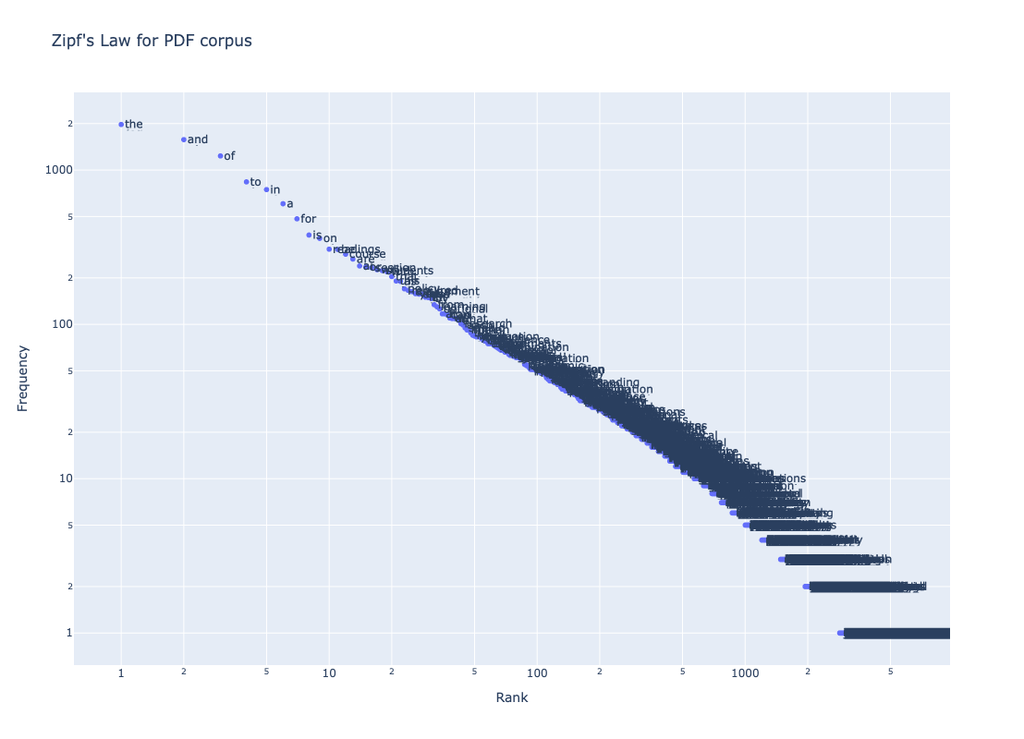

```python
plot_zipf(df_pdf_text['text'], spacy_tokenizer, log_plot=True)
```